# final_report_nba_salary

Justin Huang

2/7/2019

# Constructing a template for NBA salary negotiations

### **Introduction:**

The purpose of this report is to establish a reference point for NBA players, agents and teams in salary negotiation talks. It looks at the 3-point trend in the NBA, foreign player salaries, modern 7ft player salaries, reference for award salaries, the mid-level exception and runs a multiple linear regression in attempt to predict salary. Data was collected from the 2000 to 2018 NBA season.

### **Data Collection:**

The data was collected from a variety of sources. The data after the wrangling and cleaning contained 7978 observations with 57 variables. Salary was collected from Hoopshype a NBA third party news site that reports latest player transaction and NBA salary negotiations.

The 2000 salary data was collected from Patricia Bender’s website. Land of Basketball provided NBA award data. Player statistics was collected from basketball reference, and college and age data were collected from NBA STATs. The 4 NBA collective bargaining agreements and NBA contract structure were used as a reference to better understand salary negotiations between the Players Association and all 30 NBA owners. All the data was merged using a full_join() by player_name and named 2000_2018_nba.csv.

Below are links to the data sources:

[NBA STATS](https://stats.nba.com)（The official NBA statistics site for player and team statistics）

[Basketball Reference](https://www.basketball-reference.com)（A sports reference website that has collected historical data on all sports.）

[Patricia Bender](https://www.eskimo.com/~pbender/) (An individual who analyzed the state of the last 17 years of the CBA and provided salary information to Basketball Reference)

[CBA](http://www.cbafaq.com/salarycap.htm) (Information on the changes and agreements of the collective bargaining agreements.)

[NBA Contract](https://atlhawksfanatic.github.io/NBA-CBA/uniform-player-contract.html#bonuses) (Analyzing an NBA contract explaining the different types of contracts as well as NBA player pensions.)

[Hoops Hype](https://hoopshype.com) (NBA news site, and salary reference)

[Land of Basketball](https://www.landofbasketball.com) (Website containing historical information on awards and nominations of the NBA)

### **Data Wrangling and Cleaning:**

A few of the main challenges with this data was it was collected from different sources. Three main data sources were used, Hoopshype for salary, basketball reference for player statistics and NBA STATs for age and college information. The salary data was collected using rvest to webscrape the data tables from their website. Other data was collected through CSV files.

The main challenge with cleaning the data was that each source had different spellings for player names. Some sources had the suffixes for the name others did not, some used the passport name of the player while other sources used the American basketball name. Since each year had different players that could have a Jr or an apostrophe in their name each season was cleaned individual before using a rbind to combine them all.

Other challenges with data cleaning was to remove duplicate players, injured players, players that were legally on contract with the team but were no longer playing and players that were traded that showed up more than once in a season.

After doing a full_join() on salary, player statistic, age and college information there were still some NA’s for salary and player statistics since the number of players for each season was inconsistent for the three data sources. The reason for this is because some of the sources decided to include players that were on 2-way or 10-day contracts. 2-way contracts are for teams that are in the NBA G league. (The NBA development league.) 10- day contracts, are also contracts for players that play in the G league as well as for a way for the 30 teams to sign players left on the market to test contracts before fully committing to a player for the entire season.

Missing salary and statistic data were added back in from Patricia Benders website and basketball reference. Originally the 2019 season was also included, but I decided to remove it since the season was still ongoing at this time. I then also ran a filter to remove players that did not play more than 5 games, 5 minutes per game and did not score 1 point per game.

In the time period from 2000 to 2018, the Vancouver Grizzlies became the Memphis Grizzlies, the Seattle Supersonics became the Oklahoma City Thunder, the New Jersey Nets became the Brooklyn Nets, the Charlotte Hornets became the New Orleans Pelicans, Charlotte under the leadership of Michael Jordan got their team back and got their team back but were named the Bobcats before switching the name back to the Hornets. I chose to change the old team names to the newer one. I used grepl and gsub to perform this task. For example, from 2000 to 2007 the Seattle Supersonics team would be changed to the Oklahoma City Thunder. While, this is inaccurate it won’t affect the players data and stats, but it will keep track of team win history through 2000 to 2018.

### **Data Exploration:**

Doing an initial exploration on salary we find that the CBA structure of the 25-35 Max player contract causes the salary distribution to be skewed right. Which awards star or all-star caliber players on teams to get a majority of a team’s salary.

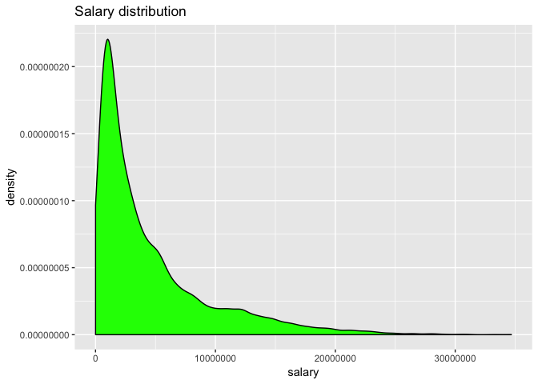

The salary structure in the NBA is a little rigid as each CBA usually lists a salary scale according to basketball related income for veterans, rookies, players signed to the mid-level exception, biannual exception, 10 day, 2- way contracts and minimum contracts.

For max salary contract players, the new 2017 CBA allows players to access the ability to get 35 percent of the that seasons salary cap. The circumstances are making an All-NBA team twice within 3 years before signing the contract or win MVP or defensive player of the year to be able to access the full max contract. The Derrick Rose rule which was set in the 2011 CBA now allows rookies to access the full max earlier now by winning MVP or making an All-NBA team twice. By not winning these awards or not playing 7-9 years in the league a player can only access 25-30 percent of the current salary cap.

Another trend is the huge salary bump in 2015 for most NBA players.

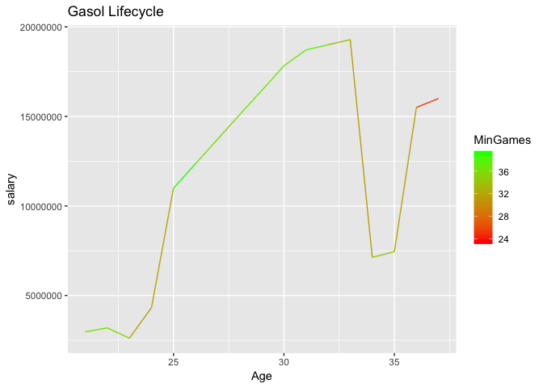

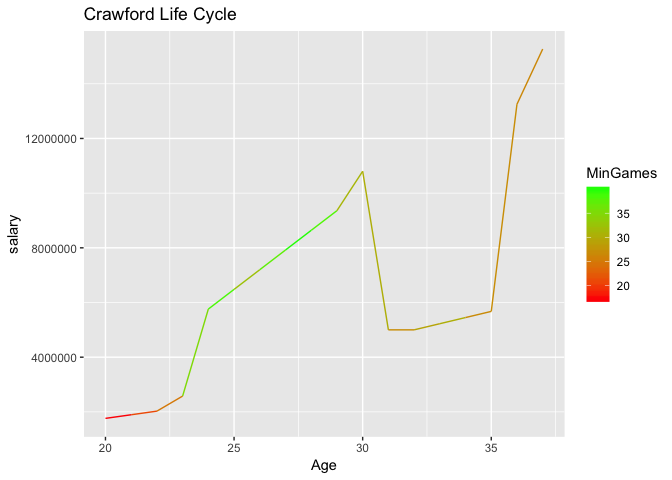

Looking at Spanish basketball player Pau Gasol who has made a few all-star teams we can see that at 35 he should be reaching the end of his NBA life cycle. Going into the 2016 season he received a huge salary boost. We can also see a similar trend for Jamal Crawford who has won multiple sixth man of the year awards also received a huge salary boost during the same year.

The sudden payment to NBA players with the huge salary cap boost can be mainly attributed to the new TV contract that the NBA signed.

[BRI](https://www.investopedia.com/articles/investing/070715/nbas-business-model.asp) – introduction to basketball related income

[TV Deal](http://www.nba.com/article/2017/04/05/nba-tv-ratings-promising-first-year-new-deal) -news article on huge NBA TV deal

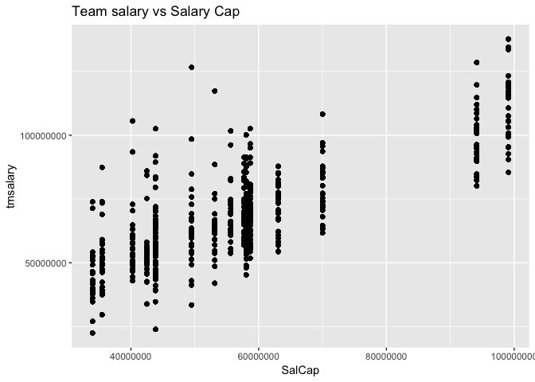

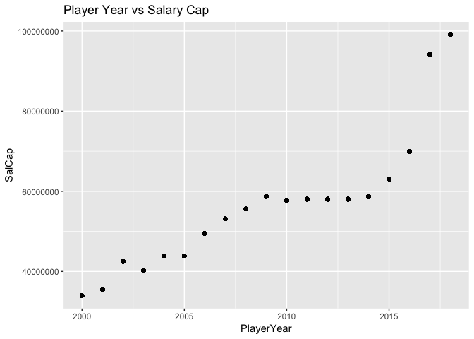

Player salary is attached to the salary cap each season which is dictated by basketball related income. Due to the increase in popularity and spread of social media and ways the league can earn revenue this could explain the huge spike in player salaries beginning after 2015. Many teams because of this anticipation of the 2017 CBA signed their players to contract structures dictated by the 2011 CBA. Thus, they gave more money to players than they usually would during the 2016 and 2017 season. A total of 2 billion dollars was spent during the 2016 free agency market.

**The salary of a 3-point shooter**

The trend in the NBA shows that more players over the years have been attempting more 3’s and taking less 2’s. Below the red dots are two-point attempts over the years and the blue dots are 3-point attempts.

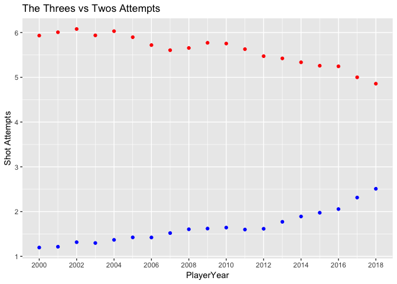

There is no strong correlation at the moment between salary and threes. However, the 3-point revolution according to many news sites started after the 2015 Championship where a jump shooting team finally won a championship.

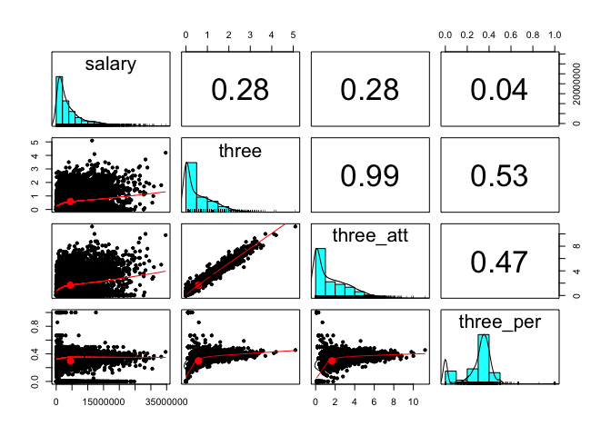

There is a weak correlation between salary and threes made (0.28), three-point attempts(0.28) and three-point percentage(0.04). However, if we look at winning compared to three pointers and separate players who made three 3pointers a game and those who did not we can see there is a big discrepancy in wins.

From the table above we can see that in the later years after 2015 for players who made more than three 3’s a game were able to win on average 55 games and the minimum amount of wins is 36.

```
## # A tibble: 11 x 5
##    PlayerYear meanW `median(TeamWins,… `max(TeamWins, n… `min(TeamWins, n…
##         <int> <dbl>              <dbl>             <int>             <int>
##  1       2002  41                 41                  41                41
##  2       2004  55                 55                  55                55
##  3       2006  35                 35                  35                35
##  4       2007  31                 31                  31                31
##  5       2008  32                 32                  32                32
##  6       2013  47                 47                  47                47
##  7       2014  42.5               42.5                51                34
##  8       2015  67                 67                  67                67
##  9       2016  63.3               73                  73                44
## 10       2017  54.9               55                  67                36
## 11       2018  57.4               58                  65                48
```

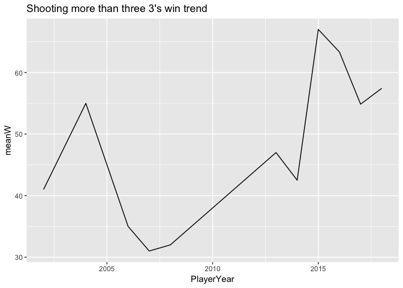

Looking at the chart we can see there was again a huge spike in 2015 for wins and making more than three 3’s. In the past due to how the game was played differently with slashing guards and post up big men there was less emphasis on the 3-point shot.

Looking at the table for less than three 3’s a game we can see that the mean is around 41 games won. With a min even as low as 7 wins.

```
## # A tibble: 19 x 5
##    PlayerYear meanW `median(TeamWins,… `max(TeamWins, n… `min(TeamWins, n…
##         <int> <dbl>              <dbl>             <int>             <int>
##  1       2000  40.1                 42                67                15
##  2       2001  40.6                 45                58                15
##  3       2002  40.9                 42                61                21
##  4       2003  40.8                 43                60                17
##  5       2004  41.0                 41                61                21
##  6       2005  40.4                 43                62                13
##  7       2006  41.1                 41                64                21
##  8       2007  40.6                 40                67                22
##  9       2008  40.6                 41                66                15
## 10       2009  40.8                 41                66                17
## 11       2010  40.1                 42                61                12
## 12       2011  40.9                 42                62                17
## 13       2012  32.8                 35                50                 7
## 14       2013  40.8                 41                66                20
## 15       2014  40.9                 43                62                15
## 16       2015  40.6                 40                67                16
## 17       2016  40.6                 42                73                10
## 18       2017  40.6                 41                67                20
## 19       2018  40.2                 44                65                21
```

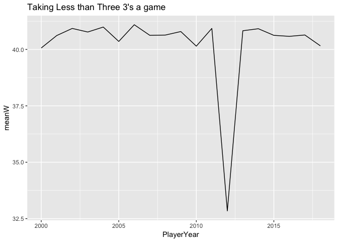

If we look at the graph, we see the average wins for players who can’t make more than three 3’s is around 40 games. The dip in 2012 is due to the shortened lock out season.

After the 2015 season it showed players who made more than 3 three’s per game on average their teams won 55 games. While, teams who had players who made less than 3 three’s a game only won on average 40-42 games. Winning 40-42 games through the 2000-2018 season would normally only get you 8th seed in the east while you would be 9th or 10th seed in the west. Therefore, as a general manager you would want to keep a look out for these players who have the ability to make more than 3 three’s a game. Out of 7978 observations only 27 observations were able to do so. While only one observation Jason Richardson was the only player who did not make an All-NBA team or win an individual award. From a team’s perspective or an agent’s perspective then these players who have the ability to make more than 3 threes a game are valuable.

```
##                name PlayerYear   salary  ppg three
## 1         Ray Allen       2002 11250000 21.8   3.3
## 2   Peja Stojakovic       2004  6250000 24.2   3.0
## 3         Ray Allen       2006 13223140 25.1   3.4
## 4         Ray Allen       2007 14611570 26.4   3.0
## 5  Jason Richardson       2008 11111110 21.8   3.0
## 6     Stephen Curry       2013  3958742 22.9   3.5
## 7     Ryan Anderson       2014  8308500 19.8   3.0
## 8     Stephen Curry       2014  9887642 24.0   3.3
## 9     Klay Thompson       2015  3075880 21.7   3.1
## 10    Stephen Curry       2015 10629213 23.8   3.6
```

```
##          Salary
## mean   14437429
## max    34682550
## min     3075880
## median 12112359
## stdev   8172376
```

The average salary for the past 19 seasons is 14437429 which should be starting talks for a team if they are able to find a player who has this capability. However, if the player dictates terms and knows his value, he could possibly dictate probably twice this amount until there are more observations in the future and there are more players in the market who have the ability to make more than 3 threes a game.

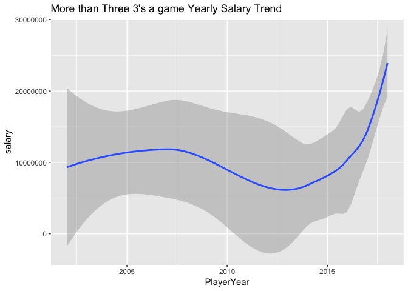

Looking at the plot above in today’s NBA market a player who has the ability to make more than three 3’s a game could possibly command a salary above 20 million dollars a year. This type of contract is near close to the max and could vary depending on the number of years the player has played in the NBA.

Benefit:

```
Scarcity of players- 27 observations out of 7978 were only able to make three 3’s a game in a season!
```

Cost:

```
Signing a player would be difficult and you would be most likely paying near the max money for this type of player and thus signing them to an unfavorable contract.

The trend analysis shows that more players are attempting 3’s hence this population of players being able to make more than 3 three’s a game might increase in the future causing the supply to go up and the price for these players to go down.
```

**Modern Day 7fters NBA Salary**

The average height of the NBA player did not decrease that much over the past 19 seasons.

The average height of the NBA player did not decrease that much over the past 19 seasons.

```
##    PlayerYear   height  salary
## 1        2000 200.9356 2880067
## 2        2001 200.9545 3398885
## 3        2002 201.5609 3487920
## 4        2003 201.6292 3783693
## 5        2004 201.3472 3817195
## 6        2005 201.4734 3911320
## 7        2006 201.0049 4091303
## 8        2007 200.6675 4140794
## 9        2008 200.8610 4574357
## 10       2009 201.2897 4715669
## 11       2010 200.9824 4829387
## 12       2011 201.3957 4560710
## 13       2012 200.9750 4348460
## 14       2013 200.8822 4447435
## 15       2014 200.9120 4402763
## 16       2015 200.8978 4430783
## 17       2016 201.1982 5097982
## 18       2017 201.1186 6218880
## 19       2018 200.5735 6450838
```

We can see average salary increased by 1.2 million dollars from 2016 to 2017. Again, this is largely due to the TV deals that was recently signed. The bar graph below shows that the number of players over 7ft tall stayed relatively the same over the 19 seasons.

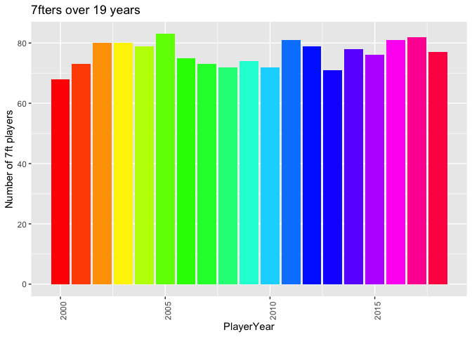

We can see big men over the height of 7ft(213cm) is still quite rare in the NBA. They only make about 10 percent of the players during each NBA season. However, height can be misleading as taller players usually list themselves shorter at 6ft 9, 10 or 11 on their player card. I decided to change the height requirement to 210 cm. A prime example of player listed height not matching actual height is Kevin Durant who is over 7ft tall but lists himself at 6ft 9 inches. Looking at the trend we can see more big men are taking more 3’s and slimming down.

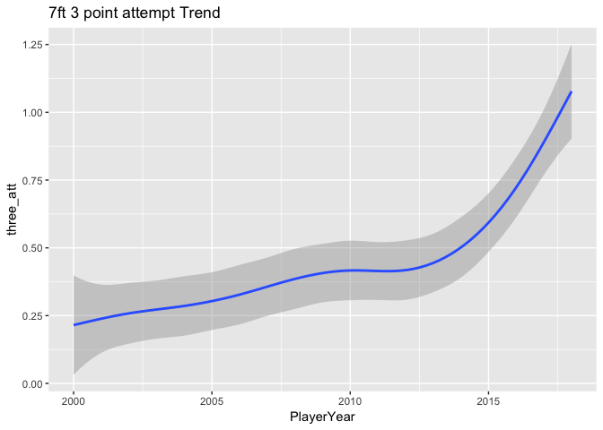

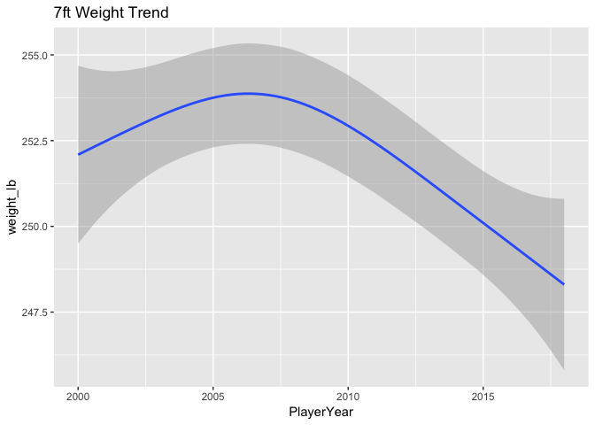

The weight metric is relatively important especially for 7fters and the rest of the NBA players as some teams do have stipulations for salary in contracts for players to stay in shape to play a much faster pace in today’s game.

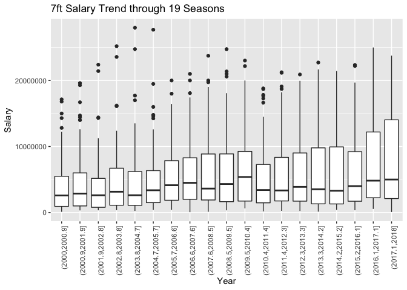

[output not shown]

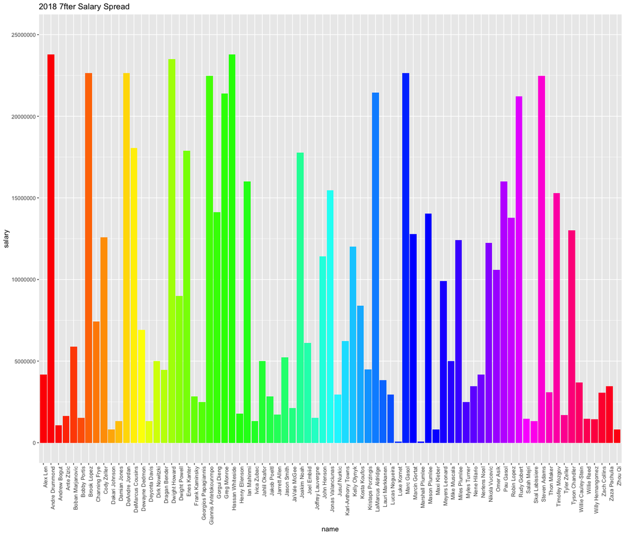

Looking at the 2018 salary spread for big men we can gain better insight on how much a quality big man should be paid under the new 2017 CBA.

Going off the 2018 contracts for 7fters, we see that the top 5 paid 7fters are Andre Drumond, Hassan Whiteside, Dwight Howard, Brook Lopez and Deandre Jordon command a salary over 20 million dollars a year.

```
##                     name   salary  ppg three t_reb block
## 1         Andre Drummond 23775506 15.0   0.0  16.0   1.6
## 2       Hassan Whiteside 23775506 14.0   0.0  11.4   1.7
## 3          Dwight Howard 23500000 16.6   0.0  12.5   1.6
## 4            Brook Lopez 22642350 13.0   1.5   4.0   1.3
## 5         DeAndre Jordan 22642350 12.0   0.0  15.2   0.9
## 6             Marc Gasol 22642350 17.2   1.5   8.1   1.4
## 7           Steven Adams 22471911 13.9   0.0   9.0   1.0
## 8  Giannis Antetokounmpo 22471911 26.9   0.6  10.0   1.4
## 9      LaMarcus Aldridge 21461010 23.1   0.4   8.5   1.2
## 10           Greg Monroe 21384175 10.3   0.0   6.9   0.5
```

Looking at the top 10 paid 7fters, the value comes from grabbing rebounds and protecting the rim. Looking at the list however, only 2 of these are traditional back to the basket big men. The rest are players who play the pick and roll or pick and pop. This is where they roll to the basket or shoot the 3-pointer or long mid-range 2-pointer. Looking at the salary amount these players are signed at 20-25 percent of the current salary cap which was 99 million dollars for the 2018 season. Depending on the market for numbers of buyers (teams with cap) and sellers (players seeking teams) these types of players could receive up to the max or the salary of a 2nd or 3rd option on a team.

The unircorn or the modern day big man is a big that can space the floor, run up and down the court, grab rebounds and block. College teams make it a priority to scout for these types of players. If we run a filter and search for these types of players, by setting a filter for scoring more than 15 ppg, making 1 three a game, grabbing 7 rebounds or more, making 1 block, having a three point percentage of 0.35 which is 5 percent above the mean average of three pointer percentage in the league and finally a height above 208 cm, we find that we only get 14 observations out of the 7978.

```
##                  name PlayerYear t_reb three  ppg block   salary Games
## 1       Dirk Nowitzki       2001   9.2   1.8 21.8   1.2  1693560    82
## 2     Rasheed Wallace       2002   8.2   1.4 19.3   1.3 14400000    79
## 3       Dirk Nowitzki       2002   9.9   1.8 23.4   1.0  2157595    76
## 4       Dirk Nowitzki       2003   9.9   1.9 25.1   1.0 10067750    80
## 5     Rasheed Wallace       2003   7.4   1.5 18.1   1.0 16200000    74
## 6       Dirk Nowitzki       2005   9.7   1.2 26.1   1.5 12584688    78
## 7       Dirk Nowitzki       2006   9.0   1.4 26.6   1.0 13843156    81
## 8          Al Horford       2016   7.3   1.1 15.2   1.5 12000000    82
## 9  Karl-Anthony Towns       2017  12.3   1.2 25.1   1.3  5960160    82
## 10   DeMarcus Cousins       2017  11.0   1.8 27.0   1.3 15756438    72
## 11 Kristaps Porzingis       2017   7.2   1.7 18.1   2.0  4317720    66
## 12        Joel Embiid       2017   7.8   1.2 20.2   2.5  4826160    31
## 13   DeMarcus Cousins       2018  12.9   2.2 25.2   1.6 18063850    48
## 14 Karl-Anthony Towns       2018  12.3   1.5 21.3   1.4  6216840    82
```

Notable players like Anthony davis did not even make this filtered list. Also, if we look at the list we can see that in reality only 7 players were able to make this filtered list. One important thing to notice is the amount of games played. Cousins, Joel Embiid both played less than 50 games while, Kristaps Porzingis only played 66 games. In general players who are taller are more prone to injury when running up and down in a contact sport. The problem with this once you commit to the max and if this player gets injured the salary still remains on the teams salary which can be ranging from 20-40 percent depending on the awards and number of years the player has played.

[7ft injury](https://tonic.vice.com/en_us/article/zmgd44/nba-tall-players-injury-basketball)- Article talking about tall players getting injured at todays pace of the game.

Benefits:

```
Signing a modern day big that can spread the floor, shoot 3’s and grab rebounds is a modern day unicorn.

Great foundation as genetics cannot be taught or trained.  These types of players should be offered the max and then the super max contract.
```

Costs:

```
Big men are injury prone.  There were many times during the exploration phase of this report that an injured big man did not play but his salary still counted towards the team that season.

Stretch provisions (to stretch a player’s contract over many years) or buyouts(negotiate a buyout of the contract to remove it from the team salary) are very costly and can stranglehold an organization for many years.

Examples:

  Yao Ming
  Kristaps Porzingis
  A’mare Stoudamire
  Dirk Nowitziki
  Greg Oden
```

**Foreign Player Salary in the NBA**

With the increase of globalization of the NBA it is important to look at international prospects and players as there might be huge player market outside the United States.

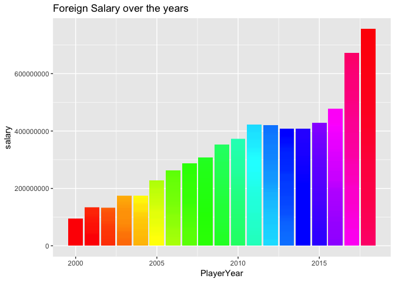

```
## # A tibble: 10 x 3
##    country   count_country    salary
##    <fct>             <int>     <dbl>
##  1 France              102 548647323
##  2 Spain                68 515601566
##  3 Brazil               62 329170240
##  4 Germany              29 278303863
##  5 Argentina            55 262352074
##  6 Turkey               45 261965589
##  7 Slovenia             52 199606417
##  8 Lithuania            27 199502355
##  9 Italy                32 197172659
## 10 Russia               32 180585067
```

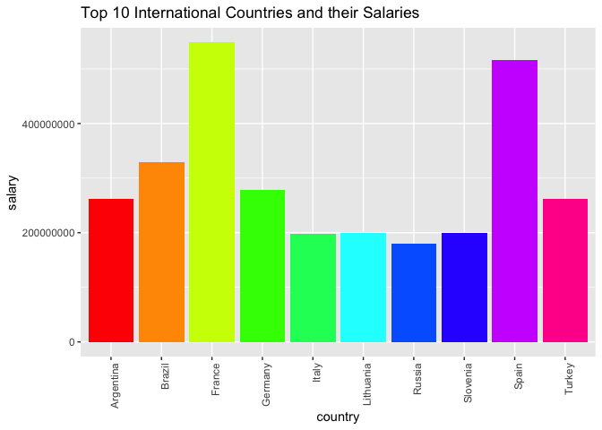

France had the most prospects 102. However, if you look at the salary it looks like Spain produced better prospects than France as the amount of money is quite similar, but Spain only had 68 observations from the 2000-2018 season.

Spain and France in the past 19 seasons have dominated the European league last 2 decades. For France notable players are Tony parker and Boris Diaw, for Spain they have the Gasol brothers. Spain also arguably has one of the best leagues outside the NBA. La Liga ACB with the most notable team Real Madrid Baloncesto. Because of the age minimum in the NBA it has forced basketball players to look at other options to play professionally before entering the NBA. One of the most recent notable players is Luka Doncic who played one season with Real Madrid before being drafted in the NBA. What makes the Spanish league attractive to players is the actual team doesn’t have a salary cap so the team can spend as much as their team president allows.

The main reason why many players from international leagues can’t make an easier transition to the NBA is they are usually legally obligated to finish out their international contracts with their club. The NBA only allows up to 600,000 dollars for teams to be spend on player contract buyouts. The rest of contract has to be bought out by the player himself. The problem with this is these international players are they are locked into lower rookie contracts which is not enough to cover the cost of their contract with their international club. Teams are allowed more flexibility in contract talks if they allow these players to drop into the 2nd round. However, the team risks the player being drafted by another team. Teams also could just maintain the rights of the player however the wait time for these players to come from oversees can be upwards to 4 years which sacrifices valuable player development time.

```
##          Salary
## mean    5002830
## max    25000000
## min       61775
## median  3149524
## stdev   4771831
```

For a salary scale we see that the mean salary for foreign players is 5,002,830 with max being 25,000,000 per year. The minimum salary for foreign players the past 19 seasons was 61775, this was probably a 10-day contract or a 2-way contract for a foreign player playing in the developmental league. International players have the benefits of also playing in the professional league at a much earlier age.

[Ricky Rubio](https://en.wikipedia.org/wiki/Ricky_Rubio) - Ricky Rubio age 15 at the Olympics.

Benefit:

```
Sign a more mature player.  European players especially can play in the professional league at the age of 15.  They could even attend world events such as the summer Olympic games.  (Ricky Rubio, Beijing 2008)

Access to an international market can bring in more revenue to the team.

Retains rights to players and can keep abroad and won’t count towards the salary cap
```

Cost:

```
600,000-dollar limit to help players with buy outs.  Rookie contracts usually 1-2 mil a year vs a Euro contract that costs 3-4 mil per year.

No buyout the player has to wait 3-4 years sacrificing valuable player development time.
```

**Analysis of the Best and Worst team salaries in the NBA**

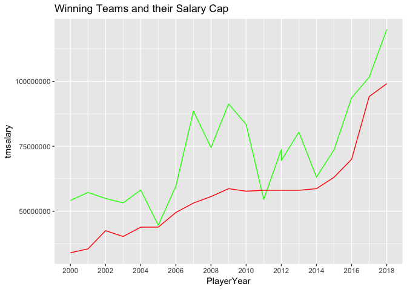

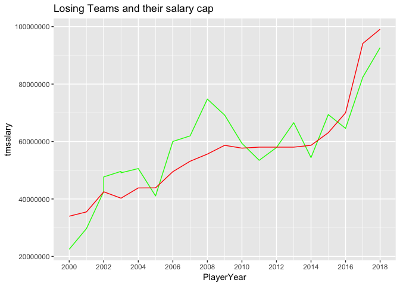

[Isaiah](https://nesn.com/2018/07/why-nba-insider-believes-isaiah-thomas-never-had-shot-at-max-contract/) -The Celtics traded Isaiah to the Cavs instead of giving him the max.

Armed with this information we as a team or an agent can better advise players for what type of team, they would want to sign with be it a team that is tanking and filling in salary or a contending championship team. Below is the top paid player on the best and worst team through the 2000-2018 season.

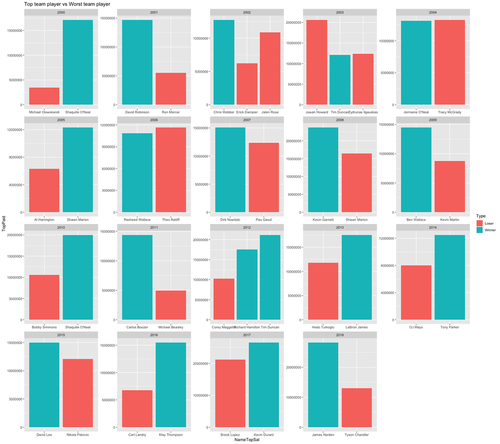

We can see that on average winning teams (teal bar) will spend more for their highest paid player than the losing team (red bar).

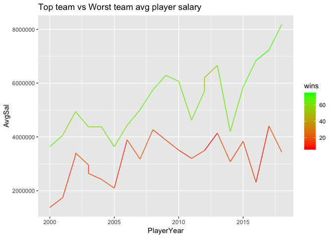

Looking at the average salary of a player through 19 seasons. Winning teams (green line) on average spend more than losing teams (red line).

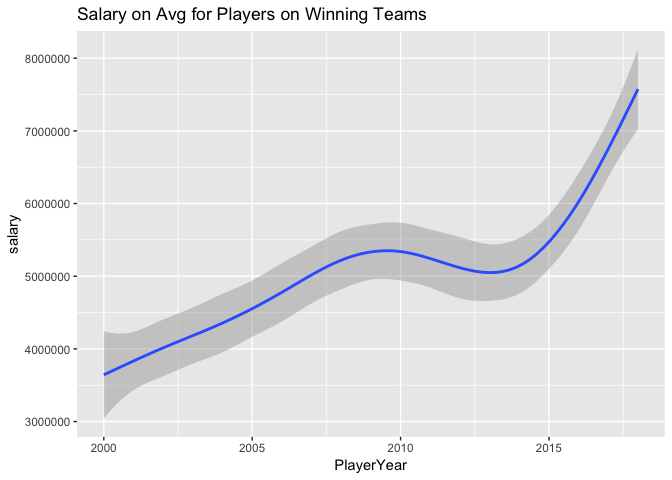

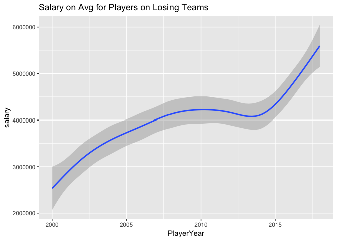

Below is a table for the benchmarks differences between winning teams and losing teams for the past 19 seasons. Again, we see more expenditure for teams with winning percentages than losing percentages. The standard deviation is bigger for the winning team salaries which confirms that the spread of salary of winning teams is more skewed as they are probably signing 1-3 huge contracts with the rest of the 12 contracts on a team being near the minimum.

```
##        Salary Win Salary Lose
## mean      5122276     4041735
## max      34682550    30453000
## min          2853        6000
## median    3033000     2446600
## stdev     5387179     4335375
```

Benefits:

```
Signing with a losing team usually has more cap space and thus could sign a better deal for the player.

Losing teams might also give a greater number of years on a contract

Winning team more team chemistry and teams might be able to sign players at a discount
```

Costs:

```
Player on a winning team might not get as much money as he wants as the team’s salary cap will most likely filled by 2 max contract players. (Taking 60 percent of the team salary)

Signing with a winning team can be instable if you aren’t the star player and many players outside the core players are usually signed to 1- or 2-year contracts.
```

**Average salary vs Award Winners Salaries and a look at the Mid-Level exception player**

The Average Joe Player showing points per game, salary, age, total rebounds and assists.

```
##         ppg  salary      age    t_reb   assist
## 1  8.356086 2880067 27.74702 3.805489 1.926969
## 2  8.421970 3398885 27.72727 3.886616 1.927273
## 3  8.605330 3487920 27.18782 3.899239 1.955838
## 4  8.443223 3783693 27.12788 3.843223 1.909719
## 5  8.566062 3817195 27.13731 3.920466 1.946891
## 6  8.751691 3911320 26.94928 3.853382 1.914010
## 7  8.699022 4091303 26.54279 3.739120 1.831051
## 8  8.775534 4140794 26.44893 3.686698 1.876960
## 9  8.801737 4574357 26.84367 3.806700 1.949132
## 10 9.029723 4715669 26.57683 3.847355 1.875819
## 11 9.028141 4829387 26.63065 3.848995 1.907035
## 12 8.773621 4560710 26.63309 3.779376 1.876499
## 13 8.311364 4348460 26.58182 3.701364 1.835682
## 14 8.513395 4447435 26.74134 3.721247 1.934180
## 15 8.694808 4402763 26.56208 3.747178 1.915124
## 16 8.568444 4430783 26.68667 3.741111 1.905333
## 17 8.797523 5097982 26.71171 3.803153 1.929505
## 18 8.970694 6218880 26.44743 3.762640 1.930425
## 19 8.973319 6450838 26.18697 3.704202 1.993277
```

Average Joe was calculated by taking the mean of all players for every season. If we look at the table, the average joe salary through 2000- 2016 changed from about 100,000 to 600,000 dollars each season. However, going into the new 2017 CBA the average salary increased by about 1.2 million dollars. Which make sense since the 2017 CBA salary scale increased for veterans, rookies that are in the lottery as well as max players.

The average salary increased over the years as well as the average player scoring more points per game.

The average salary increased over the years as well as the average player scoring more points per game.

*MVP and DPOY vs Avg Joe*

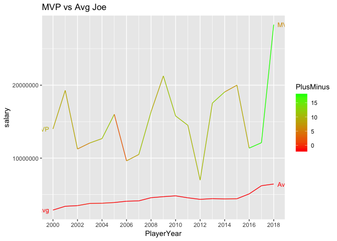

MVP salary of course is above the average joe salary. Winning the MVP award allows players to get the maximum contract. Other ways to obtain the max contract including making the All-NBA team consistently. This is in the CBA called the designated player exception.

The designated player exception: Applies to players that have 7 to 9 years of NBA experience. It allows players to get paid the max which is 35 percent of the current salary cap. Players before needed to be 10 years in the league before making 35 percent. (7 to 9 made 30, 0 to 6 made 25 percent of the salary cap.)

The requirements also are that the player must make two All-NBA teams or win defensive player of the year or MVP 3 years prior to signing the deal. We can see defensive player of the year salary is well above average Joe as well.

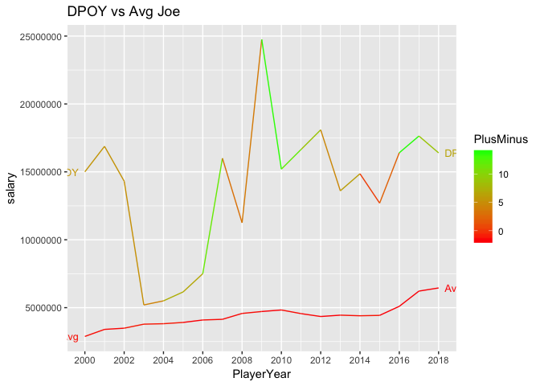

[CBA](https://www.foxsports.com/nba/story/nba-6-important-aspects-of-the-new-collective-bargaining-agreement-122016) - Explaining the collective bargaining agreement and different contract rules.

The Derrick Rose rule allows rookies to sign for 30 percent of the team salary cap if they were voted to the all-star game twice and got on two All-NBA teams. Winning the MVP would also qualify the player to get 30 percent of the salary cap.

```
##        Salary MVP Salary DPOY
## mean     15194637    13900644
## max      28299399    24751934
## min       6993708     5200000
## median   14500000    15004800
## stdev     4995717     4957578
```

We can see that MVPs make more money than players that win defensive player of the year. However, it is important to note some MVP’s have also won DPOY. While the difference doesn’t look that big between the salaries of DPOY and MVP the salary difference for playing defense and putting a good show on offense becomes more apparent when we look at the All-NBA team vs the All-defensive team.

*All-NBA and All-Defensive teams*

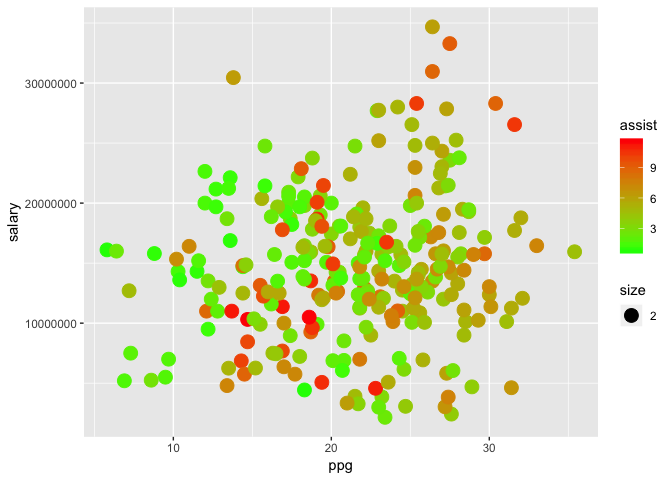

For All-NBA teams I looked at salary plotted with ppg and assists. The All-NBA team voting is widely evaluated by the media on a player’s offensive statistics and number wins. Since, the removal of the center position in the voting ballots a lot of these awards go to forwards and guards now.

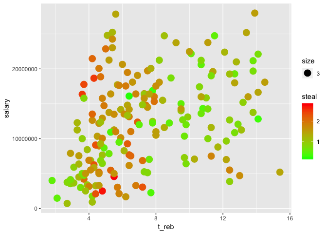

For the all-defense team I chose to plot salary with total rebounds and steals. Guards being able to easily get steals and big men being able to easily get rebounds. Of course, since this is a media chosen award, there are other non-measurable statistics on defense. For example, Bruce Bowen, Raja Bell, Avery Bradley and Shane Battier all considered good role players might not even grab a single rebound or make a single steal, but they are able to hold the opposing player to a lower shooting percentage. Thus, the all-defensive team might comprise of only a few role players in the award listing.

```
##             name PlayerYear   salary ppg block t_reb steal
## 1    Bruce Bowen       2003  3550000 7.1   0.5   2.9   0.8
## 2    Bruce Bowen       2004  3650000 6.9   0.4   3.1   1.0
## 3    Bruce Bowen       2005  3000000 8.2   0.5   3.5   0.7
## 4    Bruce Bowen       2006  3375000 7.5   0.4   3.9   1.0
## 5    Bruce Bowen       2007  3750000 6.2   0.3   2.7   0.8
## 6    Bruce Bowen       2008  4125000 6.0   0.3   2.9   0.7
## 7  Shane Battier       2009  6448900 7.3   0.9   4.8   0.8
## 8    Bruce Bowen       2009  4000000 2.7   0.2   1.8   0.5
## 9  Shane Battier       2010  6864200 8.0   1.1   4.7   0.8
## 10   Paul George       2015 15800000 8.8   0.2   3.7   0.8
## 11   Danny Green       2018 10000000 8.6   1.1   3.6   0.9
## 12    Tony Allen       2018  1471382 4.7   0.1   2.1   0.5
```

Looking at this list we can see that Bruce Bown is a prime example here as a defensive specialist but doesn’t really fill up the box score and therefore, won’t get much media attention besides winning an all defensive team award.

All-NBA players seem to receive a higher salary than All-Defense players. In NBA contracting through the agreements of the CBA there doesn’t seem to be a salary increase for players who make it to all defensive teams. If we look at the salary scale of an All-NBA player, we see that the mean salary is 14752955, max salary is 34682550, min salary is 2157595 and median salary is 14693906. Looking at the all-defensive team, the mean salary is 12274335, max salary is 28000000, min salary is 715850 and median salary is 12289544. All-NBA players are more recognized through the media and usually get voted in the yearly all-star games more often than players who are on the all-defensive team. It is important to note that most of these award voting is done not by the coaches and league players who actually play the game but the media people who cover and report interesting stories and headlines on the NBA.

```
##        Salary All_NBA Salary All_Def
## mean         14752955       12274335
## max          34682550       28000000
## min           2157595         715850
## median       14693906       12289544
## stdev         5997040        6523668
```

The benefits are clear for trying to sign the league MVP or DPOY. With most teams acknowledging these types of players should get the max. All-NBA players for consecutive years before a contract signing will be able to sign for a higher max, however all-defensive players might just be role players and might sign close to league average or the mid – level exception.

*The mid-level exception player*

The Mid-level exception is probably one of the most interesting salary exceptions allowed in the NBA. It allows teams that are at their salary cap to still sign a player at that year’s average salary. There are 3 types of mid-level exceptions.

The non-taxpayer mid-level exception, the taxpayer mid-level exception and the room mid-level exception. The non-taxpayer mid-level exception is for teams that are under that luxury tax apron which is 4 million dollars above the tax line. The amount and number of years that the player can be signed for is much less than the non-taxpayer mid-level exception. The room mid-level exception is for teams under the cap and the exception amount is the lowest as well as the number of years a player can be signed to this exception.

Before the 2011 CBA the mid-level exception was tied to salary cap. It was the average salary for all teams over the salary cap during that season. Past 2011 it has been a fixed amount each year. The mid-level exception can be used on multiple players as well.

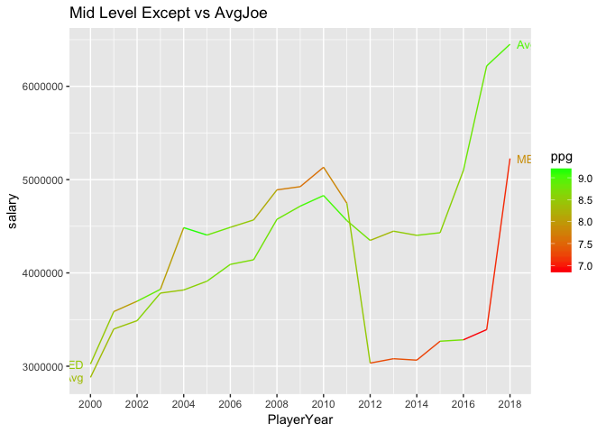

Data online for players signed by the mid-level exception wasn’t available for the last 19 seasons. What I wanted to analyze with the mid-level exception was what players each year teams could potentially sign with the mid- level exception when they were near the salary cap. The mid-level exception line above was created by taking the mid-level exception each year and selecting players whose salaries were 25 percent lower or above this mid-level exception salary number. While, of course there could be players who will be willing to take a massive pay cut to play for certain teams, this isn’t something that normally would happen on average. (David West rejected 12.5 million dollars a year to accept the veteran’s minimum with the Spurs.)

[David West](https://www.businessinsider.com/nba-david-west-spurs-pay-cut-2015-9)– Gave up 11 million dollars to sign with a contender.

It is interesting to see that players before the 2011 CBA before a fixed number was set for the mid-level exception, were able to sign better quality players on average. However, after the 2011 CBA we can see the quality drops significantly if we compare the mid- level exception player to the average players ppg we can see there is a drop off perhaps due to the salary drop.

```
##        Salary Mid Level Salary Avg Joe
## mean          4011166.4      4399391.6
## max           6352531.0      6450837.9
## min           2250000.0      2880066.5
## median        3937500.0      4402762.6
## stdev          964928.2       869631.1
```

Looking at min, max, median, mean and standard deviation, we can see that there isn’t much of a difference if you compare using the 2000-2018 season data.

Benefit:

```
Signing a player to the mid-level exception allows players who are over the cap to sign a player that is not account towards their current team salary.
```

Cost:

```
Since, the change of how the mid-level exception is calculated from a percentage of the salary cap to now a fixed amount every year.  The average salary or signing on the free-agent market is higher than what the MLE can offer.  Thus, you might not get the player you want due to another team offering him a bigger contract.
```

To attempt to build a model to predict salary I used a multiple linear regression model. For the training set I used the 2000-2014 season and for the test set the 2015-2018 season was used.

The first model used age, total rebounds, points per game, games played minutes per game, number of years and two-point shots made. I then removed two-pointers made since it wasn’t significant to the model. The adjusted R squared from that model was approximately 0.53 which means 0.47 wasn’t predicted by the model.

I then wanted to test for multicollinearity, so I ran a correlation test to see which explanatory variables were highly correlated with each other.

```
##            Age t_reb    FG   ppg Games MinGames NumYears
## Age       1.00 -0.01 -0.05 -0.05 -0.02     0.03     0.08
## t_reb    -0.01  1.00  0.62  0.58  0.41     0.66     0.41
## FG       -0.05  0.62  1.00  0.99  0.50     0.90     0.51
## ppg      -0.05  0.58  0.99  1.00  0.49     0.90     0.51
## Games    -0.02  0.41  0.50  0.49  1.00     0.60     0.38
## MinGames  0.03  0.66  0.90  0.90  0.60     1.00     0.54
## NumYears  0.08  0.41  0.51  0.51  0.38     0.54     1.00
```

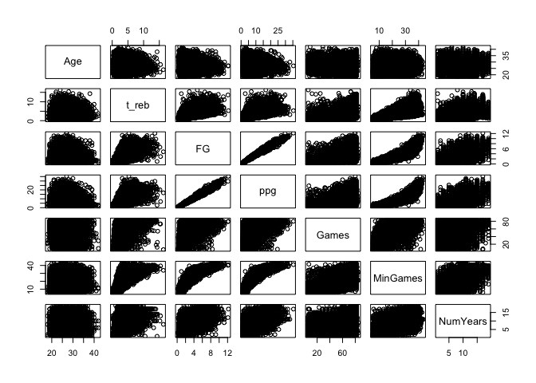

If the correlations between two explanatory variables was above 0.8 there would be a high chance of multicollinearity in the model. Field goal and points per game had a correlation of 0.99, while minutes per game, field goals and points per game had a 0.9 correlation. But before just removing these variables from the model I used a variance of inflation factor test from the cars package.

```
##       Age     t_reb        FG       ppg     Games  MinGames  NumYears
##  1.052409  2.018427 55.860798 54.848244  1.631676  7.415581  1.459289
```

```
##
## Call:
## lm(formula = salary ~ Age + t_reb + Games + ppg + NumYears, data = nbaTrain)
##
## Residuals:
##       Min        1Q    Median        3Q       Max
## -11211701  -1875320   -200382   1437061  18654055
##
## Coefficients:
##             Estimate Std. Error t value Pr(>|t|)
## (Intercept) -8855318     262677  -33.71   <2e-16 ***
## Age           325688       8820   36.92   <2e-16 ***
## t_reb         371317      19534   19.01   <2e-16 ***
## Games         -28490       2081  -13.69   <2e-16 ***
## ppg           346048       8999   38.46   <2e-16 ***
## NumYears      179648      10881   16.51   <2e-16 ***
## ---
## Signif. codes:  0 '***' 0.001 '**' 0.01 '*' 0.05 '.' 0.1 ' ' 1
##
## Residual standard error: 2992000 on 6155 degrees of freedom
## Multiple R-squared:  0.529,  Adjusted R-squared:  0.5287
## F-statistic:  1383 on 5 and 6155 DF,  p-value: < 0.00000000000000022
```

```
##      Age    t_reb    Games      ppg NumYears
## 1.016150 1.581476 1.388780 1.905876 1.442247
```

```
## [1] 2990696
```

Variance inflation is calculated as 1/tolerance where tolerance is the percent of variance in the predictor that cannot be accounted for by other predictors. We wanted to have a VIF score to be close to 1 but under 5. However, we did not want a VIF over 10 which means this variable was not needed and could be removed from the model.

Field goals had a VIF score of 55.8. Field goals was removed, and I remade the model again with field goals removed and ran the VIF test again. I then removed minutes per game which had a VIF score of 7.4. We then arrived at a model where all the VIF scores were below 5 and close to 1.

The final model before running the test for the homoscedasticity assumption had a R squared of 0.5287 with a RMSE of 2990696.

To check if the error terms were normally distributed, I ran a plot of the model. While the error terms were normally distributed by plotting it on a histogram, when I plotted it using plot(). The residuals were expanding as x increased. Thus, our assumption of homoscedasticity failed. The BP-Test confirmed heteroscedasticity.

*Box Cox Transformation of Salary*

To fix this I ran a Box Cox Transformation. Where I chose a lamda of 0.2 based off the graph.

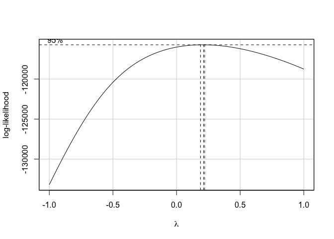

I chose a lamba of 0.2 to transform salary when looking at this chart.

```
##
## Call:
## lm(formula = salary^(0.2) ~ Age + t_reb + Games + ppg + NumYears,
##     data = nbaTrain)
##
## Residuals:
##      Min       1Q   Median       3Q      Max
## -12.2817  -1.8732   0.0329   1.9742  11.2124
##
## Coefficients:
##             Estimate Std. Error t value Pr(>|t|)
## (Intercept) 4.914164   0.250658  19.605   <2e-16 ***
## Age         0.331697   0.008417  39.409   <2e-16 ***
## t_reb       0.344405   0.018640  18.477   <2e-16 ***
## Games       0.000609   0.001986   0.307    0.759
## ppg         0.279825   0.008587  32.588   <2e-16 ***
## NumYears    0.209825   0.010383  20.209   <2e-16 ***
## ---
## Signif. codes:  0 '***' 0.001 '**' 0.01 '*' 0.05 '.' 0.1 ' ' 1
##
## Residual standard error: 2.855 on 6155 degrees of freedom
## Multiple R-squared:   0.55,  Adjusted R-squared:  0.5496
## F-statistic:  1504 on 5 and 6155 DF,  p-value: < 0.00000000000000022
```

```
## [1] 12933.74
```

For the box-cox transformation model the adjusted R-squared was 0.5496 which was an improvement over the original model. The RMSE also decreased from the original model. From 2990696 to 12933.74. The residuals became constant indicating that the model no longer suffers from heteroscedasticity.